# Weight loss predictions through linear regression

# 1 Analyis

# 2 Linear Regression with Training on PCA

Our outcome variables of weight change at 4 and 12 months were modeled as the log difference of the starting weight and final weight at 4 and 12 months. We conducted the analysis in R. We used the package FactoMineR to perform principal component analysis (PCA) on the data to reduce dimension and eliminate correlation between variables by creating new uncorrelated, orthogonal variables known as principal components (PCs).

## 2.1 PCA Results

Variables used to conduct PCA:  
• LoggedWeekDays and LoggedWeekendDays are the number of weekdays and weekend days, respectively, that include at least one entry for food, beverage, exercise, or weight. • TotalLoggedDays is the total number of days with at least one entry for food, beverage, exercise, or weight. • TotalFoodDays is the total number of days with at least one food or beverage entry was made. • TotalExerciseDays is the total number of days with at least one entry for exercise was made. • TotalBreakfastDays, TotalLunchDays, TotalDinnerDays, and TotalSnackDays are the total number of days with at least one entry for breakfast, lunch, dinner, and snack, respectively. • AverageDailyIntakeCalories is the average daily intake of calories from food over the total number of days withwhere at least one food entry. The entries for daily calories that exceeded an upper bound (i.e., 4000 kcal for women and 5000 kcal for men) and lower bound (i.e., 600 kcal for women and 800 kcal for men) were excluded for implausibility. • AverageDailyExerciseCalories is the average daily calories burned through exercise over the total number of days with at least one entry for exercise. • AverageDailyBreakfastCalories, AverageDailyLunchCalories, AverageDailyDinnerCalories, and AverageDailySnackCalories are the average daily caloric intake values over the total number of days with at least one entry for breakfast, lunch, dinner, and snack, respectively.

The 3 first principal components explains 82.2% of the variance.

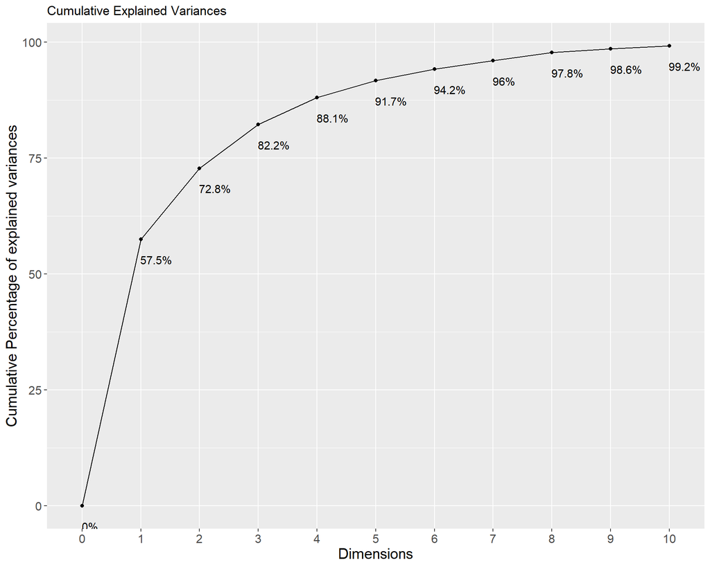

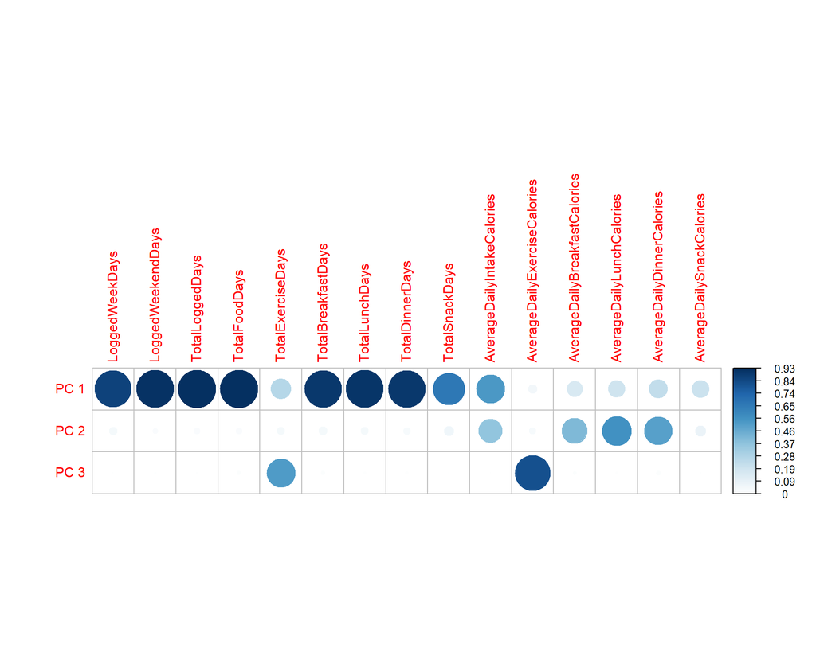

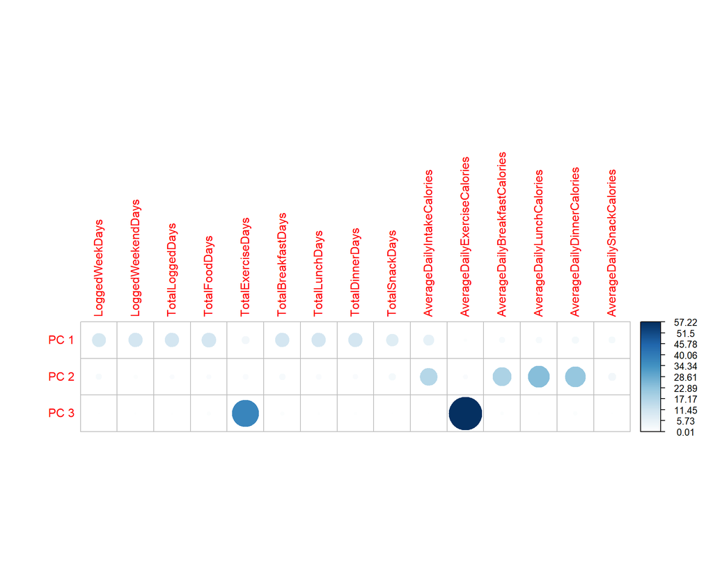

PC1 represents mainly app variables describing the frequency with which participants utilized the app. We labelled PC1 “app-usage”. PC2 describes daily caloric intake that was self-monitored by participants. We labelled PC2 labelled “app-calories”. PC3 represents participants’ exercise self-monitoring, thus we labelled PC3 “app-exercise”.

## 2.2 Results from the 8-week models

We used to primary methods of analysis, linear regression, to predict weight loss at 4 and 12 months using the first 3 PCs as predictors. We performed 5-fold cross validation (CV) on the data set.

In order to cross validate, we first divided the data into 5 folds We performed PCA on the data in 4 of the folds, trained the model on those PCs, and predicted the log weight change for the data in the fifth fold. We recorded the predictions then repeated the analysis with a permutation of folds until all data points have been predicted. Finally plot the actual vs. predicted log weight change and determine the r-squared value.

Regardless of whether we built the models without PCA variables or with PCA, 4 month predictions always had a higher r-squared value compared to 12 month predictions.

| Model | 4-month prediction $R^2$ | 4-month prediction $\rho$ | 4-month prediction mAUC | 12-month prediction $R^2$ | 12-month prediction $\rho$ | 12-month prediction mAUC |
| --- | --- | --- | --- | --- | --- | --- |
| Baseline variables (i.e., age and treatment assignment) | 0.1644 | 0.4124 | 0.6452 | 0.0575 | 0.2509 | 0.5856 |
| App-usage (PC1) + App-calories (PC2) + Self-weighing frequency | 0.3121 | 0.5788 | 0.7440 | 0.0732 | 0.2904 | 0.5718 |
| Baseline variables + App-usage (PC1) + App-calories (PC2) + Self-weighing frequency | 0.3009 | 0.5783 | 0.7331 | 0.0843 | 0.2946 | 0.5767 |
| 4- Month weight | NA | NA | NA | 0.3148 | 0.5166 | 0.6621 |

## 2.3 Linear Regression on First 8 Weeks predicting 4 Month Weight Loss with PCA App vars and baseline

### 2.3.1 Linear regression results predicting 4-month weight loss with 8-week data

|  | $\beta$ | SE | $t$ | $P$ |
| --- | --- | --- | --- | --- |
| Intercept | -0.01892 | 0.01661 | -1.13930 | 0.25642 |
| App-usage (PC1) | 0.00451 | 0.00135 | 3.33574 | 0.00108 |
| App-calories (PC2) | 0.00621 | 0.00206 | 3.01332 | 0.00304 |
| Treatment Assignment | 0.00871 | 0.00731 | 1.19274 | 0.23488 |
| Age | 0.00040 | 0.00040 | 1.00213 | 0.31792 |
| Self-weighing frequency at 8 weeks | 0.00066 | 0.00024 | 2.72883 | 0.00713 |

### 2.3.2 Linear regression results predicting 4-month weight loss with 8-week data including App-exercise (PC3)

The results indicates that the app-exercise component is not significant.

|  | $\beta$ | SE | $t$ | $P$ |
| --- | --- | --- | --- | --- |
| Intercept | -0.01772 | 0.01679 | -1.05522 | 0.29306 |
| App-usage (PC1) | 0.00453 | 0.00136 | 3.34158 | 0.00106 |
| App-calories (PC2) | 0.00627 | 0.00207 | 3.03131 | 0.00288 |
| App-exercise (PC3) | -0.00132 | 0.00243 | -0.54226 | 0.58846 |
| Treatment Assignment | 0.00856 | 0.00733 | 1.16881 | 0.24437 |
| Age | 0.00036 | 0.00040 | 0.90370 | 0.36763 |
| Self-weighing frequency at 8 weeks | 0.00066 | 0.00024 | 2.72336 | 0.00725 |

## 2.4 Linear Regression on First 8 Weeks predicting 12 Month Weight Loss with PCA App vars and baseline

The following table presents the linear regression results predicting 12-month weight loss with 8-week data.

|  | $\beta$ | SE | $t$ | $P$ |
| --- | --- | --- | --- | --- |
| Intercept | -0.06788 | 0.02613 | -2.59755 | 0.01034 |
| App-usage (PC1) | 0.00292 | 0.00205 | 1.42822 | 0.15535 |
| App-calories (PC2) | 0.00357 | 0.00306 | 1.16534 | 0.24577 |
| Treatment Assignment | 0.00672 | 0.01117 | 0.60110 | 0.54870 |
| Age | 0.00136 | 0.00061 | 2.24422 | 0.02631 |
| Self-weighing frequency at 8 weeks | 0.00079 | 0.00038 | 2.08414 | 0.03888 |

## 2.5 Linear Regression to predict 12-Month Weight Loss given the on 4-month Weight Loss

|  | $\beta$ | SE | $t$ | $P$ |
| --- | --- | --- | --- | --- |
| Intercept | -0.00407 | 0.00539 | -0.75632 | 0.45085 |
| WeightLoss4Month | 0.78234 | 0.09854 | 7.93900 | 0.00000 |